# PCA etc worked example

```r
library(compbio4all)
```

```r
library(ggpubr)
```

## Assignment

1. Write a 1 paragraph description of the dataset and the goal of the analysis. Indicate the exact table and page number that the data can from.
2. Provide a Citation for the dataset
3. Create the dataset from vectors and write a 2-3 sentence description about the process, explaining it to someone who uses Excel, not R.
4. Make a scatterplot using ggpubr::ggscater(), plotting variables against each other and useing a third for color and a fourth for size.
5. Run PCA in vegan using the rda() function
6. Write a paragraph comparing your PCA results to the original one from the reading (page x, y)
7. Run a cluster analysis that replicates how the original cluster analysis was done. Use the correct distance (cosine, Manhattan, etc) and clustering algorithm (WPGMA vs. UPGMA)
8. Write a paragraph comparing your clustering results to the original one from the reading.
9. Write a 1-paragraph conclusion summarizing to what degree you were able to replicate the original results.

## Introduction

https://www.sciencedirect.com/science/article/pii/S0003347212004824?casa_token=F0SJxpVbnZgAAAAA:mn-N8qJdirz1yGd84quoF97FRJwWGBLUXFsGObT1vJytKmfb6esEu43baKwxjibiOizL8mZfsQ#bib29

Ecology of culture: do environmental factors influence foraging tool use in wild chimpanzees, Pan troglodytes verus?

## Data

Set up dataframe from vectors.

```r
#Taï Northa Taï Southa  Yealéa,b    Bossoub,c   Seringbarab,d   Gashakae    Lopéf
#                          IC       IC     IC        Guinea  Guinea      Nigeria    Gabon
#                          1        2      3         4        5            6         7
country               <- c("IC","IC","IC","Guinea","Guinea","Nigeria","Gabon")
site                  <- c("tai_T","tai_S","yealea","bossou","seringbara","gashaka","lope")
coula_edulis          <- c(17.7, 38.8, 2.4,   0,    0,  0,   6.7)
detarium_spp          <- c(0.2,  0.1,  0.3,   0,    0,  0.1, 0.05)
elaeis_guineensis     <- c(0.01, 0.01, 4.2,  13.5,  1,  0.3, 0.9)
parinari_spp          <- c(1.3,   1.5,  1.5,   0.01, 3.4,0,   0)
panda_oleosa          <- c(0.5,  1.1,  0.2,   0,      0,    0,  0.1)
sacoglottis_gabonensis <- c(6.3,1.2,0,0,0,0,    0.8)

dat <- data.frame(country,
                  site,
                   coula_edulis,
                   detarium_spp,
                   elaeis_guineensis,parinari_spp,
                   panda_oleosa,sacoglottis_gabonensis)

row.names(dat) <-dat[,2]
```

## Scatter plot

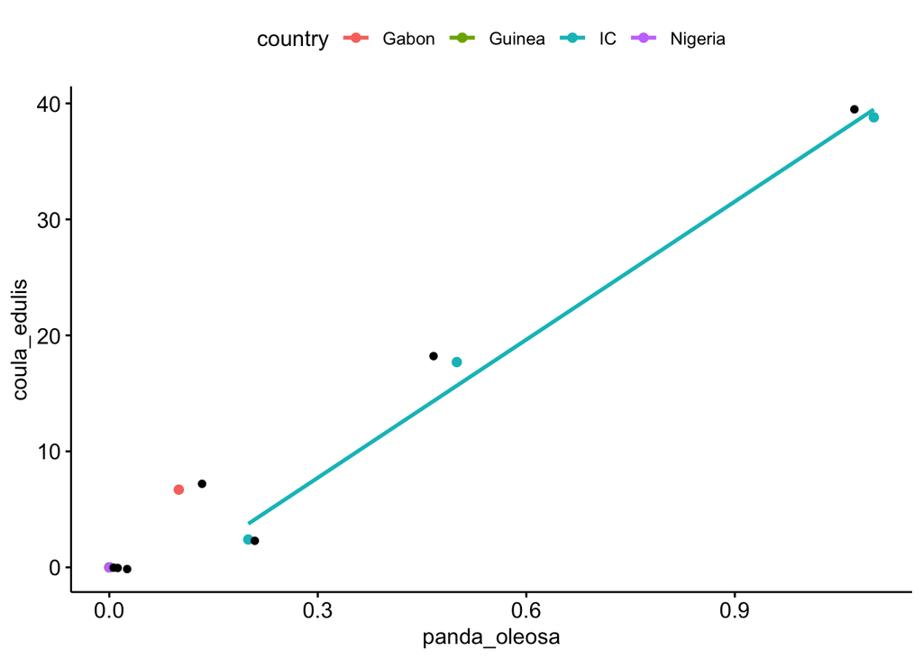

```r
ggscatter(y = "coula_edulis",
          x = "panda_oleosa",
          color = "country",
          add = "reg.line",
          # ellipse = T,
          data = dat) + geom_jitter()
```

## Cluster analysis

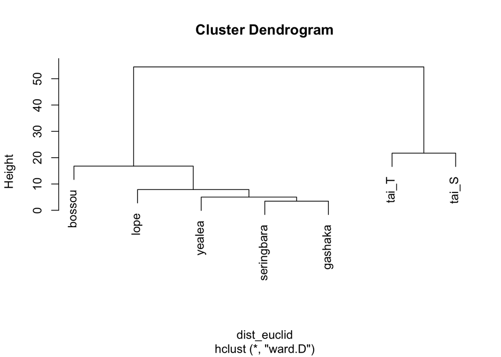

```r
dist_euclid <- dist(dat[,-c(1:2)])
clust_out <- hclust(dist_euclid,
                    method = "ward.D")
plot(clust_out,
     labels = row.names(dat))
```

Cosine distances

```r
Matrix <- as.matrix(dat[,-c(1,2)])
sim <- Matrix / sqrt(rowSums(Matrix * Matrix))
sim <- sim %*% t(sim)
#Convert to cosine dissimilarity matrix (distance matrix).

D_sim <- as.dist(1 - sim)
```

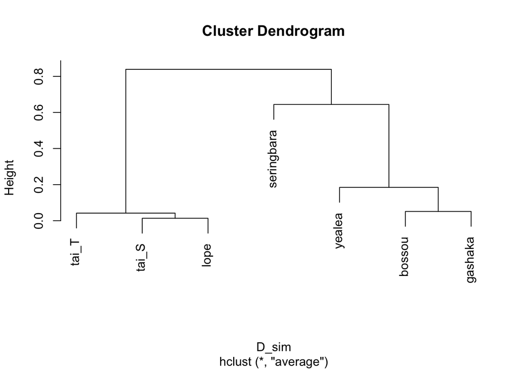

```r
clust_out <- hclust(D_sim,
                    method = "average")
plot(clust_out,
     labels = row.names(dat))
```

## PCA

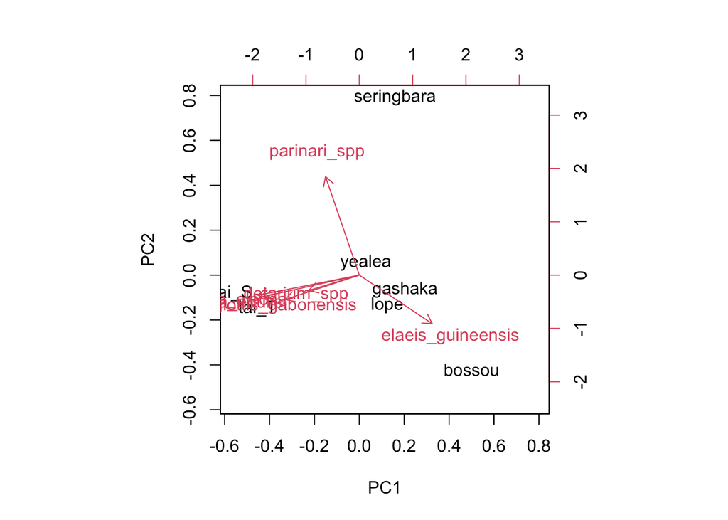

```r
biplot(prcomp(dat[,-c(1:2)],center = T,scale = T))
```

```r
library(vegan)
```

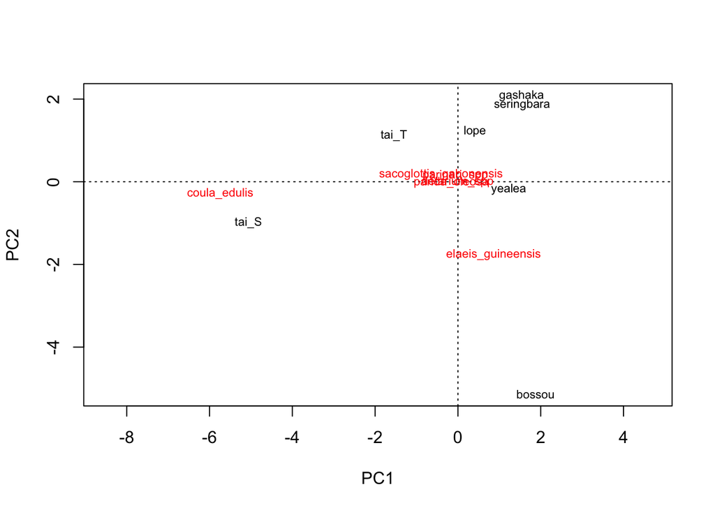

```r
vegan_pca <- rda(dat[,-c(1:2)])
plot(vegan_pca)
```